# Heart Rate and Heart Rate Variability Analysis

Jenna Lu

2026-07-27

# Overview

Heart rate variability (HRV) describes variation in the time intervals between consecutive heartbeats and provides information about autonomic nervous system regulation.

This notebook extracts cardiac timing features from filtered ECG signals collected in the WESAD dataset.

The goals are:

1. Detect cardiac R-peaks from filtered ECG
2. Calculate beat-to-beat (RR) intervals
3. Estimate instantaneous heart rate
4. Generate preliminary HRV features

# Libraries

```r
library(tidyverse)
library(here)
library(signal)
library(pracma)
```

# Load Filtered ECG Data

The filtered ECG signal generated during preprocessing is used for cardiac feature extraction.

```r
ecg_data <- read_csv(
  here(
    "data",
    "processed",
    "S2_ecg_filtered.csv"
  )
)
glimpse(ecg_data)
```

```
## Rows: 4,255,300
## Columns: 4
## $ time         <dbl> 0.000000000, 0.001428571, 0.002857143, 0.004285714, 0.005…
## $ ecg          <dbl> 0.0214233398, 0.0203247070, 0.0165252686, 0.0167083740, 0…
## $ label        <dbl> 0, 0, 0, 0, 0, 0, 0, 0, 0, 0, 0, 0, 0, 0, 0, 0, 0, 0, 0, …
## $ filtered_ecg <dbl> -0.007507003, -0.005952595, -0.004719603, -0.003923411, -…
```

# Sampling Frequency

The chest ECG signal was collected at approximately 700 Hz.

```r
fs <- 700
```

# Visualize Filtered ECG

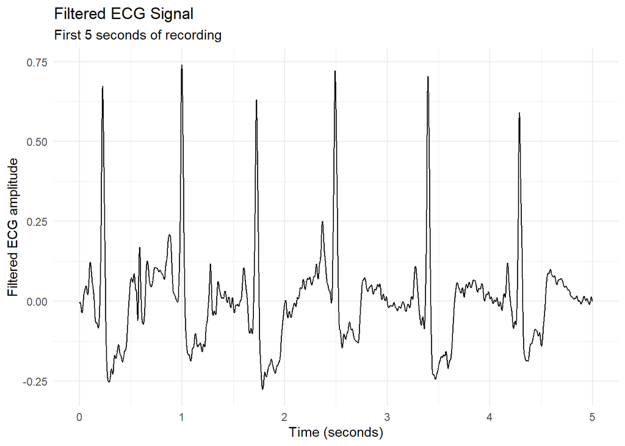

```r
ecg_data %>%
  slice(1:3500) %>%
  ggplot(
    aes(
      x = time,
      y = filtered_ecg
    )
  ) +
  geom_line() +
  labs(
    title = "Filtered ECG Signal",
    subtitle = "First 5 seconds of recording",
    x = "Time (seconds)",
    y = "Filtered ECG amplitude"
  ) +
  theme_minimal()
```

# R-Peak Detection

The R-wave represents the largest positive deflection in the ECG waveform.

The time difference between consecutive R-peaks produces RR intervals, which form the basis of heart rate and HRV analysis.

```r
ecg_signal <- ecg_data$filtered_ecg


# Detect candidate peaks

peaks <- findpeaks(
  ecg_signal,
  minpeakdistance = 350,
  threshold = 0.5
)
```

# Extract R-Peak Locations

```r
peak_indices <- peaks[,2]

peak_times <- ecg_data$time[peak_indices]

peak_times <- sort(peak_times)

length(peak_times)
```

```
## [1] 6094
```

```r
head(peak_times)
```

```
## [1] 0.2257143 0.9985714 1.7242857 2.4914286 3.3971429 4.2885714
```

# Visualize Detected Peaks

Detected peaks are overlaid on the filtered ECG waveform to assess detection quality.

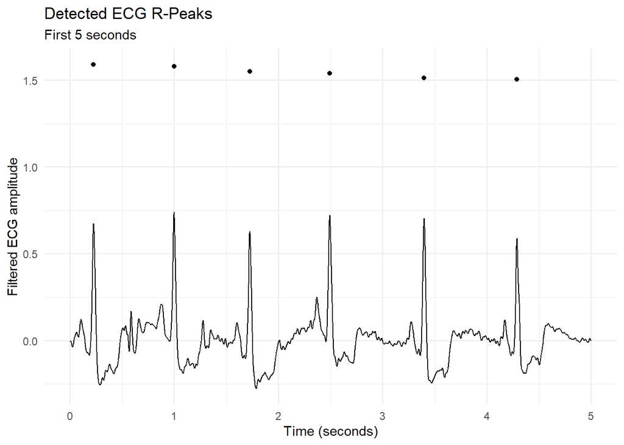

```r
ecg_data %>%
  slice(1:3500) %>%
  ggplot(
    aes(
      x=time,
      y=filtered_ecg
    )
  ) +
  geom_line() +
  geom_point(
    data = tibble(
      time = peak_times,
      value = ecg_data$filtered_ecg[peak_indices]
    ) %>%
      dplyr::filter(time <= 5),
    aes(
      x=time,
      y=value
    )
  ) +
  labs(
    title="Detected ECG R-Peaks",
    subtitle="First 5 seconds",
    x="Time (seconds)",
    y="Filtered ECG amplitude"
  ) +
  theme_minimal()
```

# Calculate RR Intervals

RR intervals represent the time between consecutive heartbeats.

```r
rr_intervals <- diff(peak_times)
rr_intervals <- rr_intervals[
  rr_intervals > 0.3 &
  rr_intervals < 2
]

summary(rr_intervals)
```

```
##    Min. 1st Qu.  Median    Mean 3rd Qu.    Max.
##  0.5000  0.8057  0.8700  0.9497  0.9443  1.9971
```

# Convert RR Intervals to Heart Rate

Heart rate is calculated as:

$$HR = \frac{60}{RR}$$

where RR is measured in seconds.

```r
heart_rate <- 60 / rr_intervals


hr_data <- tibble(
  time = peak_times[2:length(peak_times)][1:length(heart_rate)],
  heart_rate = heart_rate
)

summary(hr_data$heart_rate)
```

```
##    Min. 1st Qu.  Median    Mean 3rd Qu.    Max.
##   30.04   63.54   68.97   66.96   74.47  120.00
```

# Heart Rate Over Time

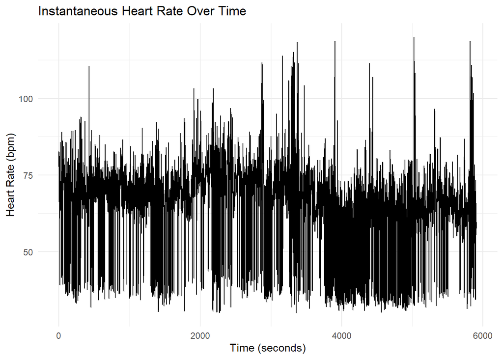

```r
ggplot(
  hr_data,
  aes(
    x=time,
    y=heart_rate
  )
) +
  geom_line() +
  labs(
    title="Instantaneous Heart Rate Over Time",
    x="Time (seconds)",
    y="Heart Rate (bpm)"
  ) +
  theme_minimal()
```

# Preliminary HRV Summary

These summary statistics describe variability in beat-to-beat intervals.

```r
hrv_summary <- tibble(
  mean_hr = mean(hr_data$heart_rate),
  sd_hr = sd(hr_data$heart_rate),
  mean_rr = mean(rr_intervals),
  sd_rr = sd(rr_intervals)
)

hrv_summary
```

```
## # A tibble: 1 × 4
##   mean_hr sd_hr mean_rr sd_rr
##     <dbl> <dbl>   <dbl> <dbl>
## 1    67.0  13.7   0.950 0.276
```

# Save Extracted Heart Rate Data

```r
write_csv(
  hr_data,
  here(
    "data",
    "processed",
    "S2_heart_rate.csv"
  )
)
```

# Summary

This notebook transforms filtered ECG recordings into interpretable cardiac features.

The extracted RR intervals and heart rate trajectories provide a lower-dimensional representation of physiological dynamics and serve as the foundation for future HRV analysis and statistical modeling.